# Generalized Linear Multilevel Models

## Introduction

We are going to look at the effect of referees in NCAA (american college) basketball games. There are studies that have shown that referees will attempt to even out calls as a game progresses. That is, they will make up calls so that the number of fouls between teams tends to be even.

- Do NCAA basketball referees “even out” in 2010. There is evidence that they did in 2005?
- How do results change if our analysis accounts for the correlation in calls from the same game and the same teams?
- Does the effect of evening out calls vary by foul type
- that is, does a ref have more control in certain situations
- There are 3 types of fouls: offensive, personal and shooting
- Do referees have an effect on the score of a game?

## The data

The data set contain every fould called in the first half of 340 games called in the NCAA in 2009-2010. The data is found in the `/data` folder.

```r
library(tidyverse)
library(broom)
library(lme4)
basketball <- readr::read_csv('data/basketball.csv') %>%
  janitor::clean_names()
basketball %>%
  glimpse()
```

```
## Rows: 4,972
## Columns: 19
## $ x1                 <dbl> 1, 2, 3, 4, 5, 6, 7, 8, 9, 10, 11, 12, 13, 14, 15, ~
## $ game               <dbl> 1, 1, 1, 1, 1, 1, 1, 1, 2, 2, 2, 2, 2, 2, 2, 2, 2, ~
## $ date               <dbl> 20100307, 20100307, 20100307, 20100307, 20100307, 2~
## $ visitor            <chr> "IA", "IA", "IA", "IA", "IA", "IA", "IA", "IA", "MI~
## $ hometeam           <chr> "MN", "MN", "MN", "MN", "MN", "MN", "MN", "MN", "MI~
## $ foul_num           <dbl> 1, 2, 3, 4, 5, 6, 7, 8, 1, 2, 3, 4, 5, 6, 7, 8, 9, ~
## $ foul_home          <dbl> 0, 1, 1, 0, 0, 0, 1, 1, 0, 1, 1, 1, 1, 0, 1, 1, 0, ~
## $ foul_vis           <dbl> 1, 0, 0, 1, 1, 1, 0, 0, 1, 0, 0, 0, 0, 1, 0, 0, 1, ~
## $ foul_diff          <dbl> 0, -1, 0, 1, 0, -1, -2, -1, 0, -1, 0, 1, 2, 3, 2, 3~
## $ score_diff         <dbl> 7, 10, 11, 11, 14, 22, 25, 23, 2, 2, 5, 5, 5, 4, 6,~
## $ lead_vis           <dbl> 0, 0, 0, 0, 0, 0, 0, 0, 0, 0, 0, 0, 0, 0, 0, 0, 0, ~
## $ lead_home          <dbl> 1, 1, 1, 1, 1, 1, 1, 1, 1, 1, 1, 1, 1, 1, 1, 1, 1, ~
## $ previous_foul_home <dbl> 0, 0, 1, 1, 0, 0, 0, 1, 0, 0, 1, 1, 1, 1, 0, 1, 1, ~
## $ previous_foul_vis  <dbl> 0, 1, 0, 0, 1, 1, 1, 0, 0, 1, 0, 0, 0, 0, 1, 0, 0, ~
## $ foul_type          <chr> "Personal", "Personal", "Personal", "Personal", "Sh~
## $ offensive          <dbl> 0, 0, 0, 0, 0, 0, 0, 1, 0, 0, 0, 0, 0, 0, 0, 0, 0, ~
## $ personal           <dbl> 1, 1, 1, 1, 0, 0, 0, 0, 0, 1, 1, 1, 0, 0, 1, 0, 0, ~
## $ shooting           <dbl> 0, 0, 0, 0, 1, 1, 1, 0, 1, 0, 0, 0, 1, 1, 0, 1, 1, ~
## $ time               <dbl> 14.1666667, 11.4333333, 10.2333333, 9.7333333, 7.76~
```

The outcome variable for this analysis will be foul_home (whether or not the next foul was called on the home team).

Our hypothesis for this analysis is that a foul called on the home team will be related to the current foul differential in the game. If more fouls have been called on the visiting team than the home team, then the next call is more likely to be a foul on the home team. Conversely, if there are currently more fouls on the home team, then the next foul called is less likely to be a home team foul.

## Data exploration

```r
basketball %>%
  head(20) %>%
  DT::datatable(caption = "first 20 rows of the basketball dataset",
                options = list(scrollX = T))
```

|  | x1 | game | date | visitor | hometeam | foul_num | foul_home | foul_vis | foul_diff | score_diff | lead_vis | lead_home | previous_foul_home | previous_foul_vis | foul_type | offensive | personal | shooting | time |
| --- | --- | --- | --- | --- | --- | --- | --- | --- | --- | --- | --- | --- | --- | --- | --- | --- | --- | --- | --- |
| 1 | 1 | 1 | 20100307 | IA | MN | 1 | 0 | 1 | 0 | 7 | 0 | 1 | 0 | 0 | Personal | 0 | 1 | 0 | 14.1666666666667 |
| 2 | 2 | 1 | 20100307 | IA | MN | 2 | 1 | 0 | -1 | 10 | 0 | 1 | 0 | 1 | Personal | 0 | 1 | 0 | 11.4333333333333 |
| 3 | 3 | 1 | 20100307 | IA | MN | 3 | 1 | 0 | 0 | 11 | 0 | 1 | 1 | 0 | Personal | 0 | 1 | 0 | 10.2333333333333 |
| 4 | 4 | 1 | 20100307 | IA | MN | 4 | 0 | 1 | 1 | 11 | 0 | 1 | 1 | 0 | Personal | 0 | 1 | 0 | 9.73333333333333 |
| 5 | 5 | 1 | 20100307 | IA | MN | 5 | 0 | 1 | 0 | 14 | 0 | 1 | 0 | 1 | Shooting | 0 | 0 | 1 | 7.76666666666667 |
| 6 | 6 | 1 | 20100307 | IA | MN | 6 | 0 | 1 | -1 | 22 | 0 | 1 | 0 | 1 | Shooting | 0 | 0 | 1 | 5.56666666666667 |
| 7 | 7 | 1 | 20100307 | IA | MN | 7 | 1 | 0 | -2 | 25 | 0 | 1 | 0 | 1 | Shooting | 0 | 0 | 1 | 2.43333333333333 |
| 8 | 8 | 1 | 20100307 | IA | MN | 8 | 1 | 0 | -1 | 23 | 0 | 1 | 1 | 0 | Offensive | 1 | 0 | 0 | 1 |
| 9 | 9 | 2 | 20100307 | MI | MIST | 1 | 0 | 1 | 0 | 2 | 0 | 1 | 0 | 0 | Shooting | 0 | 0 | 1 | 18.9833333333333 |
| 10 | 10 | 2 | 20100307 | MI | MIST | 2 | 1 | 0 | -1 | 2 | 0 | 1 | 0 | 1 | Personal | 0 | 1 | 0 | 17.2 |

[output cut: 10 more lines]

```r
# The dimensions
dim(basketball)
```

```
## [1] 4972   19
```

We have 19 variables in the dataset. They are described as follows:

- `game` = unique game id
- `date` = date game was played
- `visitor` = visiting team
- `hometeam` = home team
- `foul_num` = cumulative foul number within game
- `foul_home` = indicator if foul was called on the home team
- `foul_vis` = indicator if foul was called on the visiting team
- `foul_diff` = the difference in fouls before the current foul was called (`home` - `visitor`)
- `score_diff` = the score differential before the current foul was called (`home` - `visitor`)
- `lead_vis` = indicator if visiting team has the lead
- `lead_home` = indicator if home team has the lead
- `previous_foul_home` = indicator if previous foul was called on the home team
- `previous_foul_vis` = indicator if previous foul was called on the visiting team
- `foul_type` = categorical variable if current foul was offensive, personal, or - shooting
- `shooting` = indicator if foul was a shooting foul
- `personal` = indicator if foul was a personal foul
- `offensive` = indicator if foul was an offensive foul
- `time` = number of minutes left in the first half when foul called

```r
# number of games in the data
n_distinct(basketball$game)
```

```
## [1] 340
```

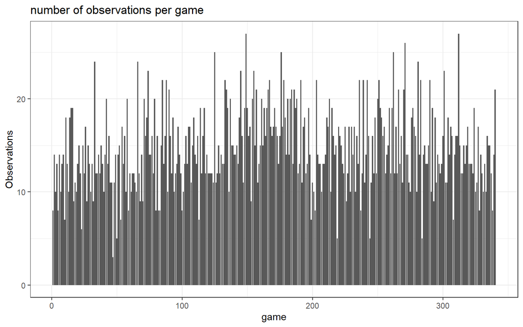

```r
basketball %>%
  count(game) %>%
  ggplot(aes(game, n)) +
  geom_bar(stat='identity') +
  labs(title = 'number of observations per game',
       y = 'Observations') +
  theme_bw()
```

```r
# number of games in the data
n_distinct(basketball$game)
```

```
## [1] 340
```

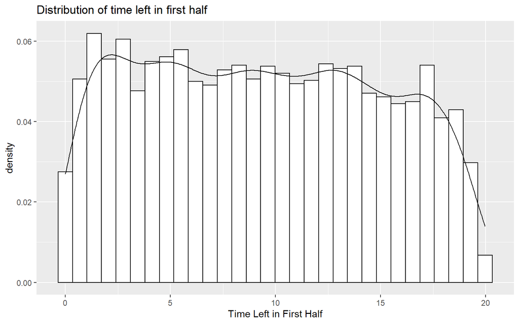

```r
basketball %>%
  ggplot(aes(time))+
  geom_histogram(aes(y=..density..), colour="black", fill="white") +
  geom_density() +
  labs(title = "Distribution of time left in first half",
       x = "Time Left in First Half")
```

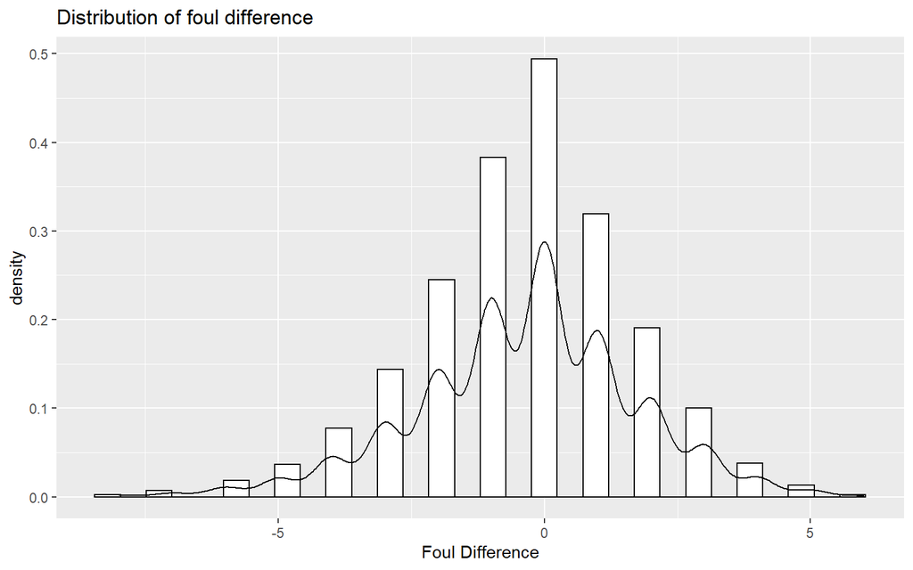

```r
basketball %>%
  ggplot(aes(foul_diff))+
  geom_histogram(aes(y=..density..), colour="black", fill="white") +
  geom_density() +
  labs(title = "Distribution of foul difference",
       x = "Foul Difference")
```

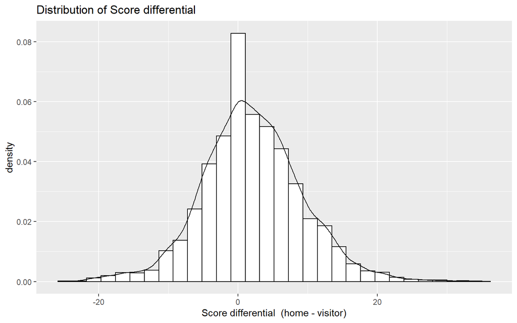

```r
basketball %>%
  ggplot(aes(score_diff))+
  geom_histogram(aes(y=..density..), colour="black", fill="white") +
  geom_density() +
  labs(title = "Distribution of Score differential",
       x = "Score differential  (home - visitor)")
```

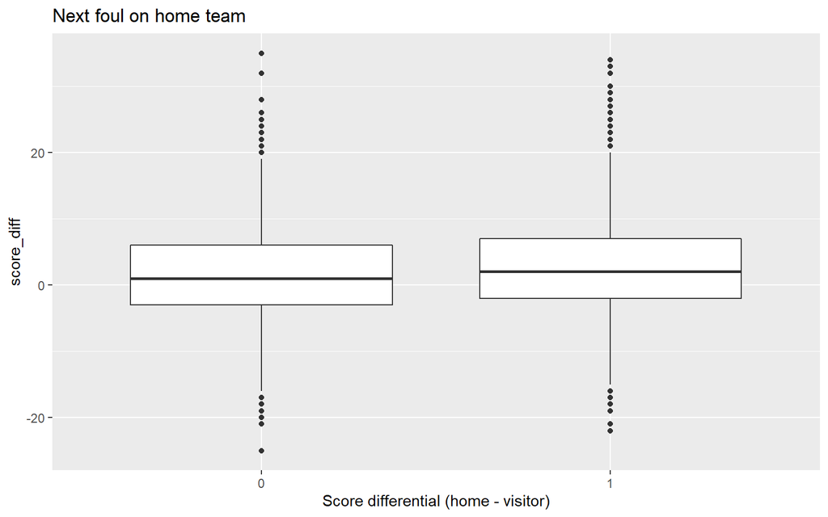

```r
basketball %>%
  ggplot(aes(factor(foul_home), score_diff))+
  geom_boxplot() +
  labs(title = "Next foul on home team",
       x = "Score differential (home - visitor)")
```

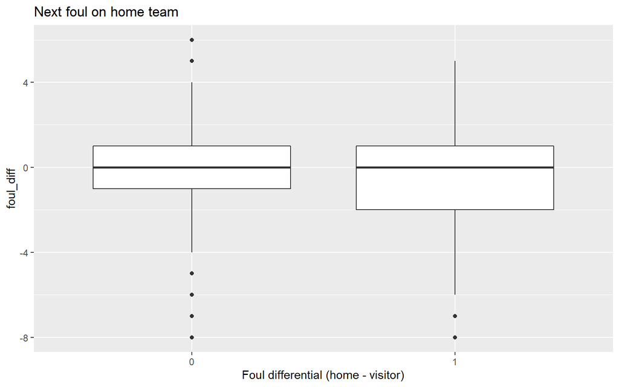

```r
basketball %>%
  ggplot(aes(factor(foul_home), foul_diff))+
  geom_boxplot() +
  labs(title = "Next foul on home team",
       x = "Foul differential (home - visitor)")
```

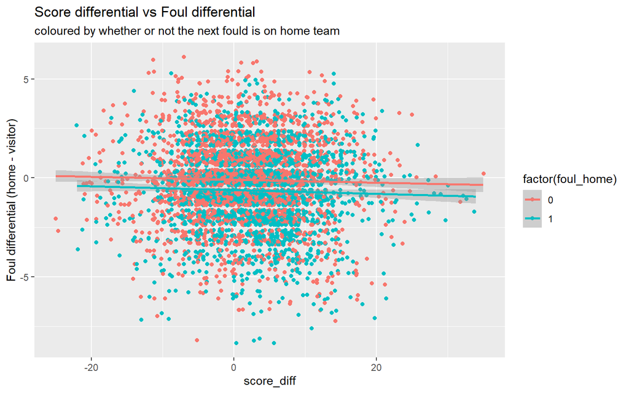

```r
basketball %>%
  ggplot(aes(score_diff, foul_diff, color = factor(foul_home)))+
  geom_jitter() +
  labs(title = "Score differential vs Foul differential",
       subtitle = "coloured by whether or not the next fould is on home team",
       y = "Foul differential (home - visitor)",
       y = "Score differential (home - visitor)") +
  geom_smooth(method="lm")
```

We plan to use the following categorical variables as level 1 inputs:

- Whether the home team has the lead
- Type of foul (offensive, personal, shooting)

```r
basketball %>%
  group_by(foul_home) %>%
  summarize(shooting_fouls = sum(foul_type == "Shooting")/n(),
            personal_fouls = sum(foul_type == "Shooting")/n(),
            offensive_fouls = sum(foul_type == "Shooting")/n(),
            home_lead_prop = sum(lead_home)/n())
```

```
## # A tibble: 2 x 5
##   foul_home shooting_fouls personal_fouls offensive_fouls home_lead_prop
##       <dbl>          <dbl>          <dbl>           <dbl>          <dbl>
## 1         0          0.395          0.395           0.395          0.529
## 2         1          0.378          0.378           0.378          0.617
```

## Model building

We start by building a logistic regression model assuming that all of the 4972 fouls are independent. That is, no correlation for game effects.

```r
mod_glm = glm(foul_home ~ foul_diff + score_diff + lead_home +
                time + foul_diff:time + lead_home:time,
              family = binomial, data = basketball)

summary(mod_glm)
```

```
##
## Call:
## glm(formula = foul_home ~ foul_diff + score_diff + lead_home +
##     time + foul_diff:time + lead_home:time, family = binomial,
##     data = basketball)
##
## Deviance Residuals:
##     Min       1Q   Median       3Q      Max
## -1.6617  -1.1225  -0.8923   1.1780   1.7777
##
## Coefficients:
##                 Estimate Std. Error z value Pr(>|z|)
## (Intercept)    -0.103416   0.101056  -1.023  0.30614
## foul_diff      -0.076599   0.024888  -3.078  0.00209 **
## score_diff      0.020062   0.006660   3.012  0.00259 **
## lead_home      -0.093227   0.160082  -0.582  0.56032
## time           -0.013141   0.007948  -1.653  0.09827 .
## foul_diff:time -0.007492   0.003014  -2.485  0.01294 *
## lead_home:time  0.021837   0.011161   1.957  0.05040 .
## ---
## Signif. codes:  0 '***' 0.001 '**' 0.01 '*' 0.05 '.' 0.1 ' ' 1
##
## (Dispersion parameter for binomial family taken to be 1)
##
##     Null deviance: 6884.3  on 4971  degrees of freedom
## Residual deviance: 6747.6  on 4965  degrees of freedom
## AIC: 6761.6
##
## Number of Fisher Scoring iterations: 4
```

```r
sjPlot::tab_model(mod_glm)
```

|  | foul home |  |  |
| --- | --- | --- | --- |
| Predictors | Odds Ratios | CI | p |
| (Intercept) | 0.90 | 0.74 – 1.10 | 0.306 |
| foul_diff | 0.93 | 0.88 – 0.97 | **0.002** |
| score_diff | 1.02 | 1.01 – 1.03 | **0.003** |
| lead_home | 0.91 | 0.67 – 1.25 | 0.560 |
| time | 0.99 | 0.97 – 1.00 | 0.098 |
| foul_diff * time | 0.99 | 0.99 – 1.00 | **0.013** |
| lead_home * time | 1.02 | 1.00 – 1.04 | 0.050 |
| Observations | 4972 |  |  |
| R<sup>2</sup> Tjur | 0.027 |  |  |

Let’s plot out the predictions for this model under a few different scenarios:

#### Scenarios

Scenario 2.

- From the start of the half to the end of the half, where the home team lead monotonically increases

Scenario 3.

- From the start of the half to the end of the half, where the home team lead monotonically decreases

Scenario 4.

- From the start of the half to the end of the half, where the score differential remains at 0, but the foul differential increases in the home team favour monotonically.

Scenario 5.

- From the start of the half to the end of the half, where the score differential remains at 0, byt the foul differential increases in the visit team favour monotonically.

Scenario 6.

- Both the home team lead and foul differential increase.

Scenario 7.

- Both the home team lead and foul differential decrease

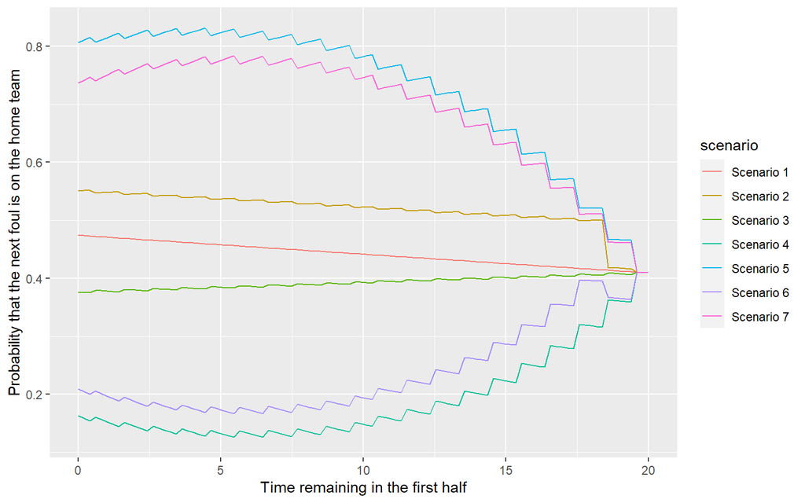

```r
scenario_1 <- data.frame(time = seq(20, 0, length.out = 100),
                       foul_diff = rep(0, 100),
                       score_diff = rep(0, 100),
                       lead_home = rep(0, 100),
                       scenario = "Scenario 1") %>%
  mutate(probability = predict(mod_glm, newdata = ., type = "response"))


scenario_2 <- data.frame(time = seq(20, 0, length.out = 100),
                       foul_diff = rep(0, 100),
                       score_diff = round(seq(0, 20, length.out = 100)),
                       scenario = "Scenario 2") %>%
  mutate(lead_home = ifelse(score_diff > 1, 1, 0)) %>%
  mutate(probability = predict(mod_glm, newdata = ., type = "response"))

scenario_3 <- data.frame(time = seq(20, 0, length.out = 100),
                       foul_diff = rep(0, 100),
                       score_diff = round(seq(0, -20, length.out = 100)),
                       scenario = "Scenario 3") %>%
  mutate(lead_home = ifelse(score_diff > 1, 1, 0)) %>%
  mutate(probability = predict(mod_glm, newdata = ., type = "response"))


scenario_4 <- data.frame(time = seq(20, 0, length.out = 100),
                       foul_diff = round(seq(0, 20, length.out = 100)),
                       score_diff = rep(0, 100),
                       scenario = "Scenario 4") %>%
  mutate(lead_home = ifelse(score_diff > 1, 1, 0)) %>%
  mutate(probability = predict(mod_glm, newdata = ., type = "response"))


scenario_5 <- data.frame(time = seq(20, 0, length.out = 100),
                       foul_diff = round(seq(0, -20, length.out = 100)),
                       score_diff = rep(0, 100),
                       scenario = "Scenario 5") %>%
  mutate(lead_home = ifelse(score_diff > 1, 1, 0)) %>%
  mutate(probability = predict(mod_glm, newdata = ., type = "response"))

scenario_6 <- data.frame(time = seq(20, 0, length.out = 100),
                       foul_diff = round(seq(0, 20, length.out = 100)),
                       score_diff = round(seq(0, 20, length.out = 100)),
                       scenario = "Scenario 6") %>%
  mutate(lead_home = ifelse(score_diff > 1, 1, 0)) %>%
  mutate(probability = predict(mod_glm, newdata = ., type = "response"))

scenario_7 <- data.frame(time = seq(20, 0, length.out = 100),
                       foul_diff = round(seq(0, -20, length.out = 100)),
                       score_diff = round(seq(0, -20, length.out = 100)),
                       scenario = "Scenario 7") %>%
  mutate(lead_home = ifelse(score_diff > 1, 1, 0)) %>%
  mutate(probability = predict(mod_glm, newdata = ., type = "response"))

scenarios <- scenario_1 %>%
  bind_rows(scenario_2) %>%
  bind_rows(scenario_3) %>%
  bind_rows(scenario_4) %>%
  bind_rows(scenario_5) %>%
  bind_rows(scenario_6) %>%
  bind_rows(scenario_7) %>%
  ggplot(aes(time, probability, color = scenario)) +
  geom_line() +
  labs(x = "Time remaining in the first half",
       y = "Probability that the next foul is on the home team")

print(scenarios)
```

This model would apply to every team and every game. We can fit some no pooling models for each game as we do below:

## Separate regression

We could fit separate logistic regressions to each game from the data as

$$log\Big(\frac{p_{game_i}}{1 - p_{game_i}}\Big) = \alpha_{game_i} + \beta_{game_i}\times\text{foul_diff}$$

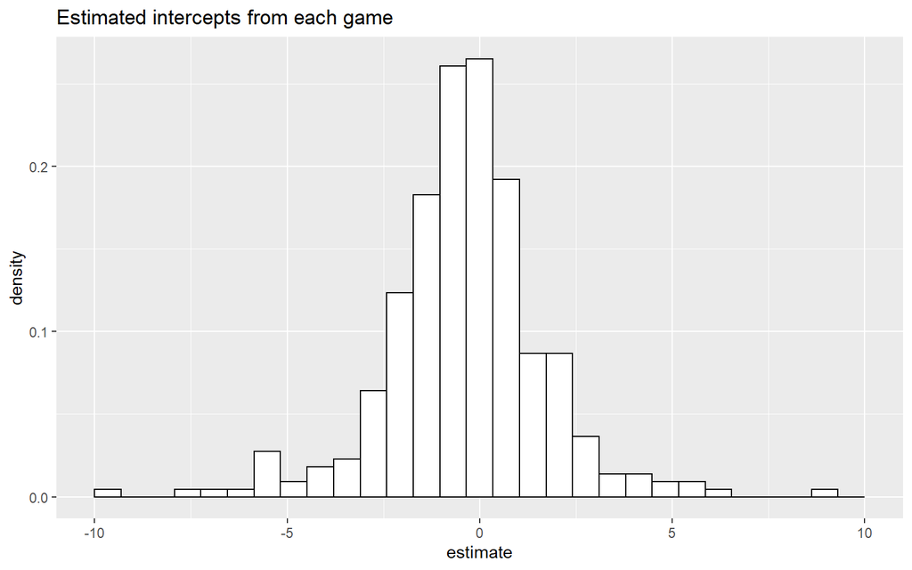

```r
grouped_regression <- basketball %>%
  group_by(game) %>%
  nest() %>%
  mutate(model = map(data, ~glm(foul_home ~ foul_diff, data = .x,
                                family = binomial) %>%
                       tidy)) %>%
  unnest(model)

grouped_regression %>%
  filter(term == "(Intercept)") %>%
  ggplot(aes(estimate)) +
  geom_histogram(aes(y=..density..), colour="black", fill="white") +
  labs(title = "Estimated intercepts from each game") +
  xlim(c(-10,10))
```

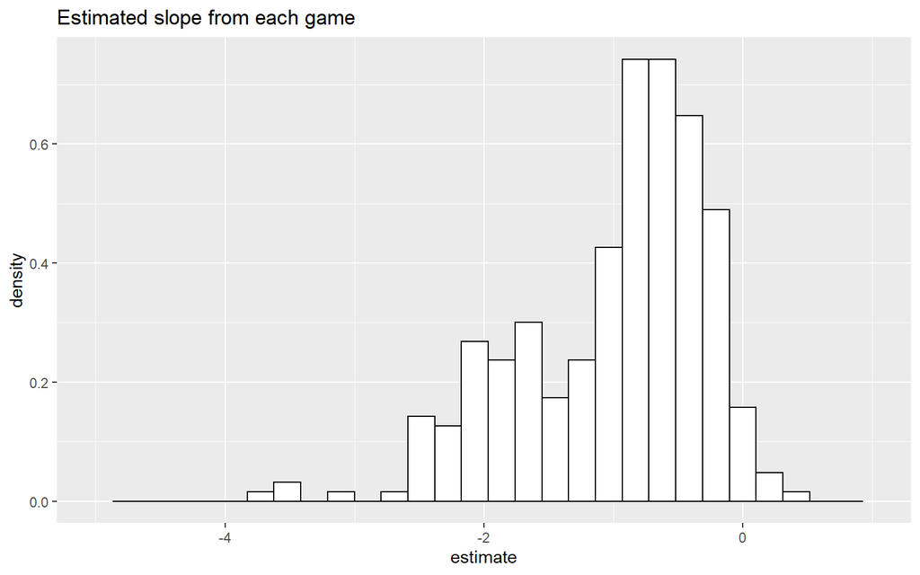

```r
grouped_regression %>%
  filter(term == "foul_diff") %>%
  ggplot(aes(estimate)) +
  geom_histogram(aes(y=..density..), colour="black", fill="white") +
  labs(title = "Estimated slope from each game") +
  xlim(c(-5,1))
```

```r
grouped_regression %>%
  filter(term == "(Intercept)") %>%
  ungroup() %>%
  summarize(q10 = quantile(estimate, .1),
            q25 = quantile(estimate, .25),
            q50 = quantile(estimate, .5),
            q75 = quantile(estimate, .75),
            q90 = quantile(estimate, .9))
```

```
## # A tibble: 1 x 5
##     q10   q25    q50   q75   q90
##   <dbl> <dbl>  <dbl> <dbl> <dbl>
## 1 -3.54 -1.45 -0.408 0.698  2.03
```

```r
grouped_regression %>%
  filter(term == "foul_diff") %>%
  ungroup() %>%
  summarize(q10 = quantile(estimate, .1),
            q25 = quantile(estimate, .25),
            q50 = quantile(estimate, .5),
            q75 = quantile(estimate, .75),
            q90 = quantile(estimate, .9))
```

```
## # A tibble: 1 x 5
##     q10   q25    q50    q75    q90
##   <dbl> <dbl>  <dbl>  <dbl>  <dbl>
## 1 -5.34 -1.81 -0.891 -0.511 -0.276
```

Most intercepts are less than zero meaning that if the foul differential is 0 (same number of fouls on the home and away team), the likelihood is that the next foul will be on the visiting team

## Multilevel Approach

We hypothesize the following multilevel model:

Level one:

$Pr(\text{foul_home} = 1) = \text{logit}^{-1}(\alpha_{j[i]} +\beta_{j[i]}\times \text{foul_diff}_i )$$

Level two:

$$\binom{\alpha_j}{\beta_j} \sim N\Big(\binom{0}{0},
\begin{pmatrix}
\sigma_{\alpha}^2 & \rho\sigma_{\alpha}\sigma_{\beta} \\
\sigma_{\alpha}^2 & \sigma_{\beta}^2
\end{pmatrix}\Big)$$

Below we fit this model with `glmer()`. This is the multilevel model equivalent of `glm()`. Specifying the random components of the model are the same with `glmer()` as it is with the `lmer` function we have used so far, and specifying the distribution assumptions is the as it is with the `glm()` function.

```r
mlm_1 <- glmer(foul_home ~ foul_diff + (foul_diff|game),
               family = binomial, data = basketball)
```

```
## boundary (singular) fit: see ?isSingular
```

```r
summary(mlm_1)
```

```
## Generalized linear mixed model fit by maximum likelihood (Laplace
##   Approximation) [glmerMod]
##  Family: binomial  ( logit )
## Formula: foul_home ~ foul_diff + (foul_diff | game)
##    Data: basketball
##
##      AIC      BIC   logLik deviance df.resid
##   6791.1   6823.6  -3390.5   6781.1     4967
##
## Scaled residuals:
##     Min      1Q  Median      3Q     Max
## -1.6399 -0.9087 -0.6349  0.9528  1.7687
##
## Random effects:
##  Groups Name        Variance Std.Dev. Corr
##  game   (Intercept) 0.294145 0.54235
##         foul_diff   0.001235 0.03514  -1.00
## Number of obs: 4972, groups:  game, 340
##
## Fixed effects:
##             Estimate Std. Error z value Pr(>|z|)
## (Intercept) -0.15684    0.04637  -3.382 0.000719 ***
## foul_diff   -0.28533    0.03835  -7.440 1.01e-13 ***
## ---
## Signif. codes:  0 '***' 0.001 '**' 0.01 '*' 0.05 '.' 0.1 ' ' 1
##
## Correlation of Fixed Effects:
##           (Intr)
## foul_diff 0.192
## optimizer (Nelder_Mead) convergence code: 0 (OK)
## boundary (singular) fit: see ?isSingular
```

```r
complete_pool <- glm(foul_home ~ foul_diff, family = binomial,
                     data = basketball)
summary(complete_pool)
```

```
##
## Call:
## glm(formula = foul_home ~ foul_diff, family = binomial, data = basketball)
##
## Deviance Residuals:
##     Min       1Q   Median       3Q      Max
## -1.5817  -1.1227  -0.9654   1.1772   1.5225
##
## Coefficients:
##             Estimate Std. Error z value Pr(>|z|)
## (Intercept) -0.13005    0.02912  -4.466 7.98e-06 ***
## foul_diff   -0.13047    0.01426  -9.148  < 2e-16 ***
## ---
## Signif. codes:  0 '***' 0.001 '**' 0.01 '*' 0.05 '.' 0.1 ' ' 1
##
## (Dispersion parameter for binomial family taken to be 1)
##
##     Null deviance: 6884.3  on 4971  degrees of freedom
## Residual deviance: 6798.1  on 4970  degrees of freedom
## AIC: 6802.1
##
## Number of Fisher Scoring iterations: 4
```

Notice that the fixed effect of foul differential is much larger here than it was for the complete pooling model.

## Crossed random effect model

Below we measure the average foul calls for home and visit teams by team name.

```r
basketball %>%
  group_by(hometeam, game) %>%
  summarize(home_fouls = sum(foul_home),
            visit_fouls = sum(foul_vis)) %>%
  group_by(hometeam) %>%
  summarize(mean_home_fouls = mean(home_fouls),
            visit_home_fouls = mean(visit_fouls)) %>%
  ungroup() %>%
  mutate(diff = mean_home_fouls - visit_home_fouls) %>%
  arrange((diff))
```

```
## # A tibble: 39 x 4
##    hometeam mean_home_fouls visit_home_fouls  diff
##    <chr>              <dbl>            <dbl> <dbl>
##  1 PUR                 5.67             8.67 -3
##  2 SYR                 5.56             8.33 -2.78
##  3 CT                  6.22             8.78 -2.56
##  4 DUKE                8.88            11.1  -2.25
##  5 WV                  6.11             8.33 -2.22
##  6 PROV                6.44             8.22 -1.78
##  7 CLEM                6.88             8.62 -1.75
##  8 NC                  5.88             7.62 -1.75
##  9 PSU                 5.6              7.3  -1.7
## 10 MN                  5.3              6.8  -1.5
## # ... with 29 more rows
```

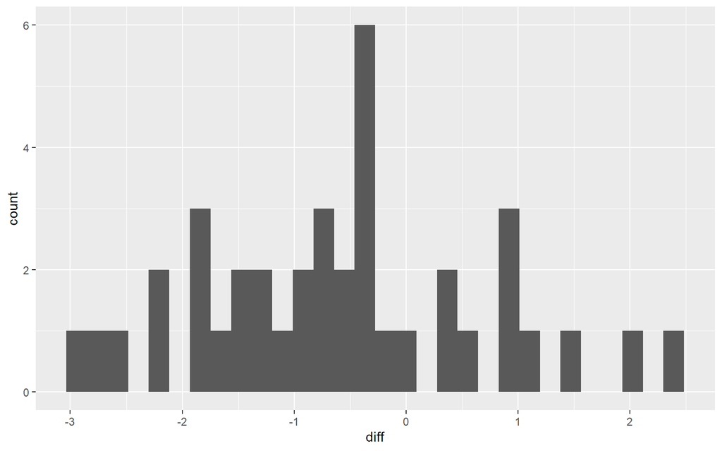

```r
basketball %>%
  group_by(hometeam, game) %>%
  summarize(home_fouls = sum(foul_home),
            visit_fouls = sum(foul_vis)) %>%
  group_by(hometeam) %>%
  summarize(mean_home_fouls = mean(home_fouls),
            visit_home_fouls = mean(visit_fouls)) %>%
  ungroup() %>%
  mutate(diff = mean_home_fouls - visit_home_fouls) %>%
  ggplot(., aes(diff)) +
  geom_histogram()
```

It appears there might be information by the team name. We could add these into our glm model, but this would involve adding 38 indicators for the home team and 38 indicators for the visiting team.

By adding these indicator variables we would complicate our model despite the fact that we’re not very interested in specific coefficient estimates for each team—we just want to control for teams playing to draw stronger conclusions about referee bias.

We will add level two crossed effects for the home and visiting team.

We will fit a random intercept model with crossed effects by game and team

Our model is as follows:

Level one:

$$Pr(\text{foul_home} = 1) = \text{logit}^{-1}(\alpha_{j[i]} +\beta_{j[i]}\times \text{foul_diff}_i )$$

Level two:

$\alpha_j = \alpha_\mu + u_i + v_h + w_g$

That is our intercept has some population mean and then variance from the game, the home team, and the visiting team. We assume the following

$$u_j \sim N(0, \sigma_\mu^2)$$

$$v_h \sim N(0, \sigma_v^2)$$

$$w_g \sim N(0, \sigma_w^2)$$

Where

- $\alpha_\mu$ is the population log odds across all games and fouls
- $u$ is the effect of the game
- $v$ is the effect of the home team and
- $w$ is the effecct of the away team

```r
mlm_2 <- glmer(foul_home ~ foul_diff + (1|game) +
                 (1|hometeam) + (1|visitor),
               family = binomial, data = basketball)
summary(mlm_2)
```

```
## Generalized linear mixed model fit by maximum likelihood (Laplace
##   Approximation) [glmerMod]
##  Family: binomial  ( logit )
## Formula: foul_home ~ foul_diff + (1 | game) + (1 | hometeam) + (1 | visitor)
##    Data: basketball
##
##      AIC      BIC   logLik deviance df.resid
##   6780.5   6813.0  -3385.2   6770.5     4967
##
## Scaled residuals:
##     Min      1Q  Median      3Q     Max
## -1.6589 -0.9056 -0.6522  0.9679  1.7952
##
## Random effects:
##  Groups   Name        Variance Std.Dev.
##  game     (Intercept) 0.17164  0.4143
##  hometeam (Intercept) 0.06809  0.2609
##  visitor  (Intercept) 0.02323  0.1524
## Number of obs: 4972, groups:  game, 340; hometeam, 39; visitor, 39
##
## Fixed effects:
##             Estimate Std. Error z value Pr(>|z|)
## (Intercept) -0.18780    0.06331  -2.967  0.00301 **
## foul_diff   -0.26385    0.03883  -6.795 1.09e-11 ***
## ---
## Signif. codes:  0 '***' 0.001 '**' 0.01 '*' 0.05 '.' 0.1 ' ' 1
##
## Correlation of Fixed Effects:
##           (Intr)
## foul_diff 0.256
```

Our model is summarized as follows

What can we say with these estimates?

- $\sigma_u^2/(\sigma_u^2 + \sigma_v^2 + \sigma_w^2)$ 0.1716/(0.1716 + 0.06809 + 0.02323) = 0.65, so 65% of the variance in the intercept is explained by game to game variance.
- $\sigma_v^2/(\sigma_u^2 + \sigma_v^2 + \sigma_w^2)$ 0.06809/(0.1716 + 0.06809 + 0.02323) = 0.26, so 26% of the variance in the intercept is explained by variance between home teams.
- $\sigma_w^2/(\sigma_u^2 + \sigma_v^2 + \sigma_w^2)$ 0.02323/(0.1716 + 0.06809 + 0.02323) = 0.09, so 9% of the variance in the intercept is explained by variance between visiting teams.

## Final model

```r
final_model <- glmer(foul_home ~ foul_diff + score_diff +
                       lead_home + time + offensive + personal +
                       foul_diff:offensive + foul_diff:personal +
                       foul_diff:time + lead_home:time + (1|game) +
                       (1|hometeam) + (1|visitor),
                     family = binomial, data = basketball)

summary(final_model)
```

```
## Generalized linear mixed model fit by maximum likelihood (Laplace
##   Approximation) [glmerMod]
##  Family: binomial  ( logit )
## Formula: foul_home ~ foul_diff + score_diff + lead_home + time + offensive +
##     personal + foul_diff:offensive + foul_diff:personal + foul_diff:time +
##     lead_home:time + (1 | game) + (1 | hometeam) + (1 | visitor)
##    Data: basketball
##
##      AIC      BIC   logLik deviance df.resid
##   6731.0   6822.2  -3351.5   6703.0     4958
##
## Scaled residuals:
##     Min      1Q  Median      3Q     Max
## -2.1268 -0.8958 -0.5831  0.9457  2.6830
##
## Random effects:
##  Groups   Name        Variance Std.Dev.
##  game     (Intercept) 0.18463  0.4297
##  hometeam (Intercept) 0.07832  0.2799
##  visitor  (Intercept) 0.04312  0.2076
## Number of obs: 4972, groups:  game, 340; hometeam, 39; visitor, 39
##
## Fixed effects:
##                      Estimate Std. Error z value Pr(>|z|)
## (Intercept)         -0.246471   0.133960  -1.840 0.065785 .
## foul_diff           -0.171459   0.045362  -3.780 0.000157 ***
## score_diff           0.033521   0.008236   4.070  4.7e-05 ***
## lead_home           -0.150621   0.177213  -0.850 0.395356
## time                -0.008747   0.008560  -1.022 0.306889
## offensive           -0.080762   0.111232  -0.726 0.467795
## personal             0.067206   0.065397   1.028 0.304109
## foul_diff:offensive -0.103579   0.053869  -1.923 0.054504 .
## foul_diff:personal  -0.055643   0.031948  -1.742 0.081560 .
## foul_diff:time      -0.008690   0.003274  -2.654 0.007947 **
## lead_home:time       0.026007   0.012172   2.137 0.032627 *
## ---
## Signif. codes:  0 '***' 0.001 '**' 0.01 '*' 0.05 '.' 0.1 ' ' 1
##
## Correlation of Fixed Effects:
##             (Intr) fl_dff scr_df led_hm time   offnsv persnl fl_dff:f fl_dff:p
```

[output cut: 8 more lines]

```
## foul_dff:tm -0.011 -0.398 -0.042 -0.008  0.049 -0.014 -0.015  0.012    0.013
## lead_hom:tm  0.564 -0.045  0.386 -0.828 -0.743 -0.011 -0.020 -0.008   -0.005
##             fl_dff:t
## foul_diff
## score_diff
## lead_home
## time
## offensive
## personal
## fl_dff:ffns
## fl_dff:prsn
## foul_dff:tm
## lead_hom:tm  0.024
## optimizer (Nelder_Mead) convergence code: 0 (OK)
## Model failed to converge with max|grad| = 0.0902622 (tol = 0.002, component 1)
```

There is a significant negative effect of foul differential—a strong tendency for referees to even out foul calls when one team starts amassing more fouls than the other.

Important covariates to control for (because of their effects on the odds of a home foul) include score differential, whether the home team held the lead, time left in the first half, and the type of foul called.

We can plot these fixed effects as follows:

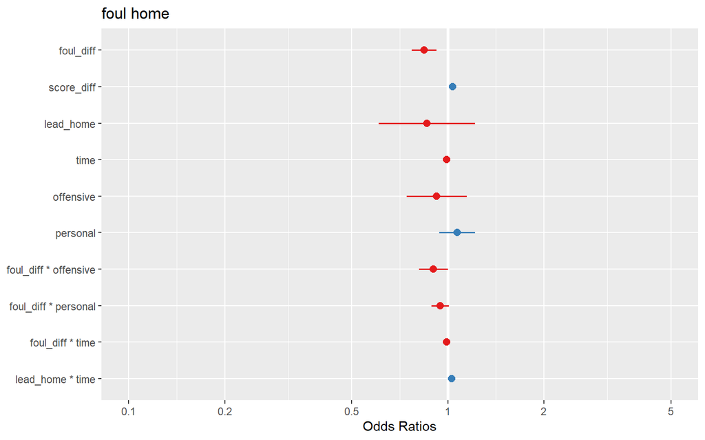

```r
library(sjPlot)
plot_model(final_model)
```

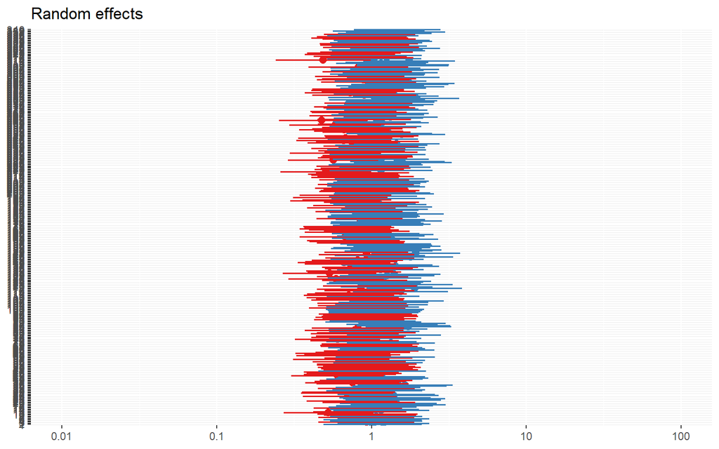

```r
p <- plot_model(final_model, type = "re", facet.grid=FALSE)
# random effect by game
p[[1]]
```

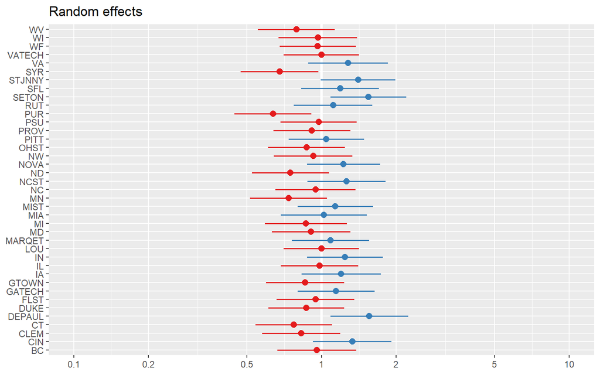

```r
# random effect by home team
p[[2]]
```

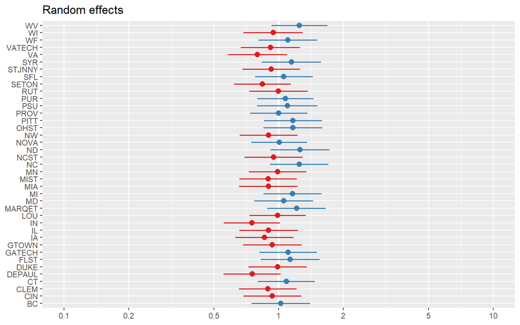

```r
# random effect by visiting team
p[[3]]
```